# Teste de hipotese

```r
knitr::opts_chunk$set(
    echo = TRUE,
    message = FALSE,
    warning = FALSE,
    cache = FALSE
)
setwd("~/ANOVA")

# Pacotes e Funções
library(tidyverse) # Manipulacao eficiente de dados
```

```r
library(ggplot2)
library(dplyr)
library(pdftools)
library(RRPP)
library(plotrix)
library(purrr)
```

# 1 Contexto do estudo

Neste estudo foram realizados diversos testes para verificar a hipótese de que há diferença estatisticamente significante no enquadramento de candidatos á presidência no Brasil. Não foi possível aplicar ANOVA e test t devido a grande quantidade de valores zerados, ou seja, os dados não possuem curva normal, sendo que a aplicação desses testes não seria válida. Foi então escolhido um teste para dados não paramétricos para avaliar cada candidato com a média do univers, Teste Wilcoxon.

# 2 Testando Hipóteses com Teste Wilcoxon - Primeiro turno

A diferença é calculada com a fórmula abaixo:

$Diferença = Positivo + Neutro - Negativo$

## 2.1 Médias da diferença de todos os candidatos

```r
DT::datatable(aggregate(Diferenca ~ Candidato, data = Tidy_Calculado_1T, mean))
```

|  | Candidato | Diferenca |
| --- | --- | --- |
| 1 | ALCKMIN | 10.1931330472103 |
| 2 | BOLSONARO | 13.0290519877676 |
| 3 | CIRO | 10.9692671394799 |
| 4 | HADDAD | 10.488 |
| 5 | MARINA | 9.78657074340528 |

## 2.2 Teste Haddad 1T

Testando a hipótese que Haddad tem a diferença de Positivo + Neutro - Negativo menor que a média do universo.

```r
 m <- mean(Tidy_Calculado_1T$Diferenca)


Haddad <- Tidy_Calculado_1T %>%
             filter(Candidato == "HADDAD")


wilcox.test(Haddad$Diferenca, mu=m)
```

```
##
##  Wilcoxon signed rank test with continuity correction
##
## data:  Haddad$Diferenca
## V = 7955, p-value = 1.366e-11
## alternative hypothesis: true location is not equal to 11.13756
```

A média de Haddad (10.488) é menor que a média do universo (11.13756), e essa diferença é estatisticamente significante, segundo o teste Wilcoxon.

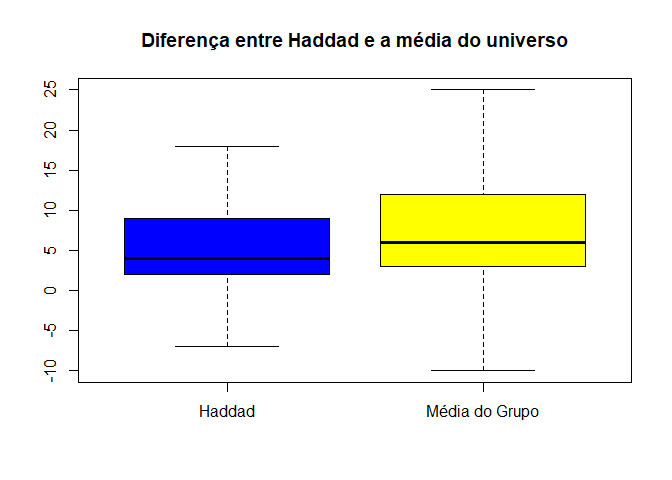

```r
boxplot(Haddad$Diferenca, Tidy_Calculado_1T$Diferenca,
        outline = FALSE,
        names = c("Haddad", "Média do Grupo"),
        col = c("blue", "yellow"),
        main = "Diferença entre Haddad e a média do universo")
```

## 2.3 Teste Bolsonaro 1T - facada e Bolsonaro

Testando a hipótese que Bolsonaro mais os enquadramentos da facada somados, tem a diferença de Positivo + Neutro - Negativo maior que a média do universo.

```r
Bolsonaro <- Tidy_Calculado_1T %>%
             filter(Candidato == "BOLSONARO")


wilcox.test(Bolsonaro$Diferenca, mu=m)
```

```
##
##  Wilcoxon signed rank test with continuity correction
##
## data:  Bolsonaro$Diferenca
## V = 72989, p-value = 1.683e-12
## alternative hypothesis: true location is not equal to 11.13756
```

A média de Bolsonaro (13.02905) é maior que a média do universo (11.13756), e essa diferença é estatisticamente significante, segundo o teste Wilcoxon.

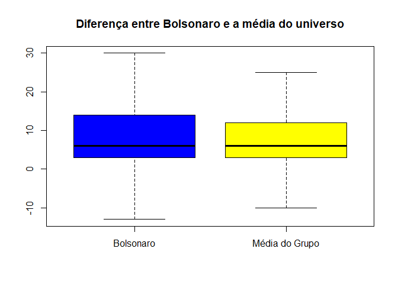

```r
boxplot(Bolsonaro$Diferenca, Tidy_Calculado_1T$Diferenca,
        outline = FALSE,
        names = c("Bolsonaro", "Média do Grupo"),
        col = c("blue", "yellow"),
        main = "Diferença entre Bolsonaro e a média do universo")
```

## 2.4 Teste Ciro 1T

Testando a hipótese que Ciro tem a diferença de Positivo + Neutro - Negativo maior que a média do universo.

```r
Ciro <- Tidy_Calculado_1T %>%
             filter(Candidato == "CIRO")


t.test(Ciro$Diferenca, mu=m)
```

```
##
##  One Sample t-test
##
## data:  Ciro$Diferenca
## t = -0.18797, df = 422, p-value = 0.851
## alternative hypothesis: true mean is not equal to 11.13756
## 95 percent confidence interval:
##   9.209421 12.729113
## sample estimates:
## mean of x
##  10.96927
```

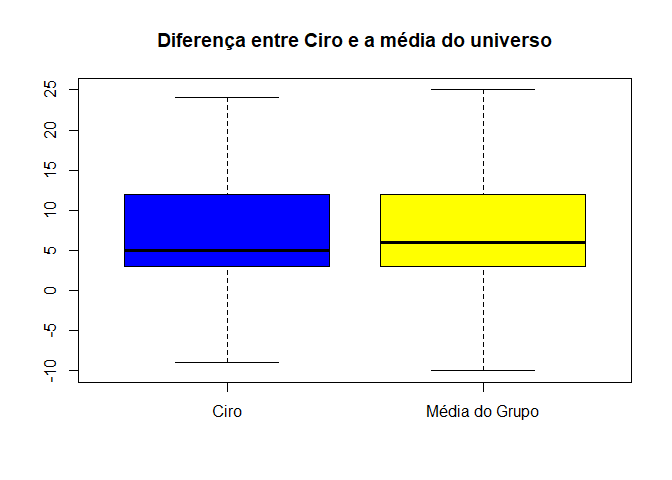

```r
boxplot(Ciro$Diferenca, Tidy_Calculado_1T$Diferenca,
        outline = FALSE,
        names = c("Ciro", "Média do Grupo"),
        col = c("blue", "yellow"),
        main = "Diferença entre Ciro e a média do universo")
```

## 2.5 Teste Marina 1T

Testando a hipótese que Marina tem a diferença de Positivo + Neutro - Negativo maior que a média do universo.

```r
Marina <- Tidy_Calculado_1T %>%
             filter(Candidato == "MARINA")


wilcox.test(Marina$Diferenca, mu=m)
```

```
##
##  Wilcoxon signed rank test with continuity correction
##
## data:  Marina$Diferenca
## V = 21901, p-value < 2.2e-16
## alternative hypothesis: true location is not equal to 11.13756
```

A média de Marina (9.786571) é menor que a média do universo (11.13756), e essa diferença é estatisticamente significante, segundo o teste Wilcoxon.

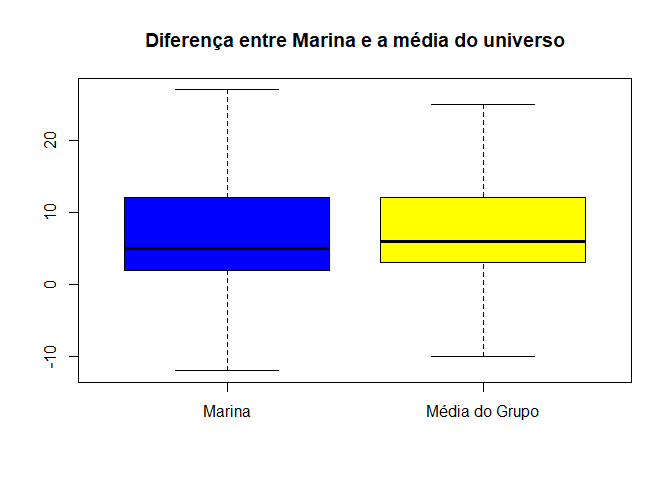

```r
boxplot(Marina$Diferenca, Tidy_Calculado_1T$Diferenca,
        outline = FALSE,
        names = c("Marina", "Média do Grupo"),
        col = c("blue", "yellow"),
        main = "Diferença entre Marina e a média do universo")
```

## 2.6 Teste Alckmin 1T

Testando a hipótese que Alkimin tem a diferença de Positivo + Neutro - Negativo menor que a média do universo.

```r
Alckmin <- Tidy_Calculado_1T %>%
             filter(Candidato == "ALCKMIN")


wilcox.test(Alckmin$Diferenca, mu=m)
```

```
##
##  Wilcoxon signed rank test with continuity correction
##
## data:  Alckmin$Diferenca
## V = 26697, p-value < 2.2e-16
## alternative hypothesis: true location is not equal to 11.13756
```

A média de Alckmin (10.19313) é menor que a média do universo (11.13756), e essa diferença é estatisticamente significante, segundo o teste Wilcoxon.

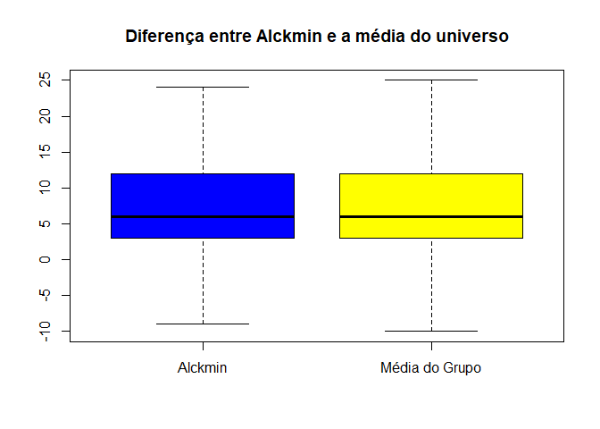

```r
boxplot(Alckmin$Diferenca, Tidy_Calculado_1T$Diferenca,
        outline = FALSE,
        names = c("Alckmin", "Média do Grupo"),
        col = c("blue", "yellow"),
        main = "Diferença entre Alckmin e a média do universo")
```

## 2.7 Conclusão do Primeiro turno

Somando os enquadramentos positivos e neutros e diminuindo os enquadramentos negativos, o candidato mais beneficiado no primeiro turno foi Bolsonaro. Bolsonaro foi o único candidato que teve a média da diferença (Posito + Neutro - Negativo) estatisticamente maior que a média do universo, utilizando o teste Wilcoxon (para amostras com dados não normalizados).

# 3 Testes de hipóteses no Segundo turno

Calculo da Diferença = $Positivo + Neutro - Negativo$ de cada candidato com a média do universo, utilizando o teste Wilcoxon (para amostras com dados não normalizados).

## 3.1 Médias da diferença de todos os candidatos no segundo turno

```r
DT::datatable(aggregate(Diferenca ~ Candidato, data = Tidy_Calculado_2T, mean))
```

|  | Candidato | Diferenca |
| --- | --- | --- |
| 1 | BOLSONARO | 359.875 |
| 2 | HADDAD | 359.117647058824 |

## 3.2 Teste Haddad 2T

Testando a hipótese que Haddad tem a diferença de Positivo + Neutro - Negativo menor que a média do universo.

```r
 m2 <- mean(Tidy_Calculado_2T$Diferenca)


Haddad2 <- Tidy_Calculado_2T %>%
             filter(Candidato == "HADDAD")


wilcox.test(Haddad2$Diferenca, mu=m2)
```

```
##
##  Wilcoxon signed rank test
##
## data:  Haddad2$Diferenca
## V = 43, p-value = 0.1202
## alternative hypothesis: true location is not equal to 359.4848
```

A média de Haddad (359.1176) é estatisticamente igual a média do universo (359.4848), segundo o teste Wilcoxon.

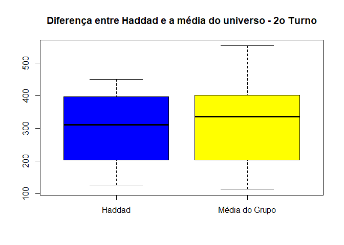

```r
boxplot(Haddad2$Diferenca, Tidy_Calculado_2T$Diferenca,
        outline = FALSE,
        names = c("Haddad", "Média do Grupo"),
        col = c("blue", "yellow"),
        main = "Diferença entre Haddad e a média do universo - 2o Turno")
```

## 3.3 Teste Bolsonaro 2T

```r
Bolsonaro2 <- Tidy_Calculado_2T %>%
             filter(Candidato == "BOLSONARO")


wilcox.test(Bolsonaro2$Diferenca, mu=m2)
```

```
##
##  Wilcoxon signed rank test
##
## data:  Bolsonaro2$Diferenca
## V = 66, p-value = 0.9399
## alternative hypothesis: true location is not equal to 359.4848
```

A média de Bolsonaro (359.875) é estatisticamente igual a média do universo (359.4848), segundo o teste Wilcoxon.

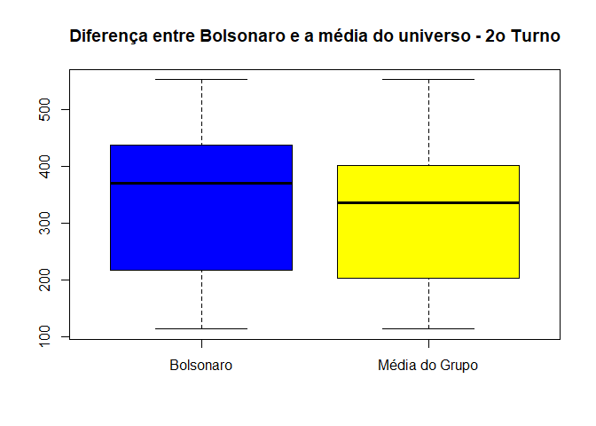

```r
boxplot(Bolsonaro2$Diferenca, Tidy_Calculado_2T$Diferenca,
        outline = FALSE,
        names = c("Bolsonaro", "Média do Grupo"),
        col = c("blue", "yellow"),
        main = "Diferença entre Bolsonaro e a média do universo - 2o Turno")
```

## 3.4 Conclusão do segundo turno

Apesar de haver diferença nas médias dos candidatos, essa diferença não é significativa estatisticamente. Assim, não é possivel afirmar que algum candidato tenha sido beneficiado com os enquadramentos do JN no 2o Turno.